# R Notebook

Week 11 Day 5 Logistic Regression Homework

You have been provided with a set of data on customer purchases of either ‘Citrus Hill’ (purchase = ‘CH’) or ‘Minute Maid’ (purchase = ‘MM’) orange juice, together with some further attributes of both the customer and the store of purchase. A data dictionary is also provided in the data directory.

We would like you to build the best predictive classifier you can of whether a customer is likely to buy Citrus Hill or Minute Maid juice. Use logistic regression to do this. You should use either train-test splitting or cross-validation to evaluate your classifier. The metric for ‘best classifier’ will be highest AUC value either in the test set (for train-test splitting) or from cross-validation.

Tips: - can do automated, or manual - the purchase variable will require wrangling - wrangle other categorical variables into factors - weekofpurchase is also tough; decide on a stategy - check for aliased variables

```r
# loading libraries

library(tidyverse)
library(janitor)
library(GGally)
library(janitor)
library(modelr)
library(broom)
library(pROC)
library(caret)
```

```r
# loading data

juice <- read_csv("data/orange_juice.csv")
```

```r
# getting overview of data / EDA
head(juice)
```

| Purchase | WeekofPurchase | StoreID | PriceCH | PriceMM | DiscCH | DiscMM | SpecialCH | SpecialMM | LoyalCH | SalePriceMM | SalePriceCH | PriceDiff | Store7 | PctDiscMM | PctDiscCH | ListPriceDiff | STORE |
| --- | --- | --- | --- | --- | --- | --- | --- | --- | --- | --- | --- | --- | --- | --- | --- | --- | --- |
| CH | 237 | 1 | 1.75 | 1.99 | 0.00 | 0.0 | 0 | 0 | 0.500000 | 1.99 | 1.75 | 0.24 | No | 0.000000 | 0.000000 | 0.24 | 1 |
| CH | 239 | 1 | 1.75 | 1.99 | 0.00 | 0.3 | 0 | 1 | 0.600000 | 1.69 | 1.75 | -0.06 | No | 0.150754 | 0.000000 | 0.24 | 1 |
| CH | 245 | 1 | 1.86 | 2.09 | 0.17 | 0.0 | 0 | 0 | 0.680000 | 2.09 | 1.69 | 0.40 | No | 0.000000 | 0.091398 | 0.23 | 1 |
| MM | 227 | 1 | 1.69 | 1.69 | 0.00 | 0.0 | 0 | 0 | 0.400000 | 1.69 | 1.69 | 0.00 | No | 0.000000 | 0.000000 | 0.00 | 1 |
| CH | 228 | 7 | 1.69 | 1.69 | 0.00 | 0.0 | 0 | 0 | 0.956535 | 1.69 | 1.69 | 0.00 | Yes | 0.000000 | 0.000000 | 0.00 | 0 |
| CH | 230 | 7 | 1.69 | 1.99 | 0.00 | 0.0 | 0 | 1 | 0.965228 | 1.99 | 1.69 | 0.30 | Yes | 0.000000 | 0.000000 | 0.30 | 0 |

```r
# looking closer at weekofpurchase - the problem is similar to the one in the PDA task

juice %>%
  select(WeekofPurchase) %>%
  distinct(WeekofPurchase) %>%
  arrange(WeekofPurchase)
```

| WeekofPurchase |
| --- |
| 227 |
| 228 |
| 229 |
| 230 |
| 231 |
| 232 |
| 233 |
| 234 |
| 235 |
| 236 |

[output cut: 42 more lines]

```r
# there are 52 distinct rows, i.e. 1 per week. They can't be converted into months (would be 4.3), but they CAN be converted into quarters (13)
```

```r
# cleaning the data

juice_clean <- juice %>%
  clean_names() %>%
  mutate(purchase_mm = as.factor(ifelse(purchase == "MM", "T", "F")),
         store_id = as.factor(store_id),
         special_ch = as.factor(special_ch),
         special_mm = as.factor(special_mm),
         store7 = as.factor(store7),
         store = as.factor(store)) %>%
  select(-purchase, -weekof_purchase)
```

Checking for aliased variables

```r
alias(purchase_mm ~ ., data = juice_clean)
```

```
Model :
purchase_mm ~ store_id + price_ch + price_mm + disc_ch + disc_mm +
    special_ch + special_mm + loyal_ch + sale_price_mm + sale_price_ch +
    price_diff + store7 + pct_disc_mm + pct_disc_ch + list_price_diff +
    store

Complete :
                (Intercept) store_id2 store_id3 store_id4 store_id7 price_ch price_mm disc_ch disc_mm special_ch1 special_mm1 loyal_ch pct_disc_mm pct_disc_ch
sale_price_mm    0           0         0         0         0         0        1        0      -1       0           0           0        0           0
sale_price_ch    0           0         0         0         0         1        0       -1       0       0           0           0        0           0
price_diff       0           0         0         0         0        -1        1        1      -1       0           0           0        0           0
store7Yes        0           0         0         0         1         0        0        0       0       0           0           0        0           0
list_price_diff  0           0         0         0         0        -1        1        0       0       0           0           0        0           0
store1           1          -1        -1        -1        -1         0        0        0       0       0           0           0        0           0
store2           0           1         0         0         0         0        0        0       0       0           0           0        0           0
store3           0           0         1         0         0         0        0        0       0       0           0           0        0           0
store4           0           0         0         1         0         0        0        0       0       0           0           0        0           0
```

There are multiple here which are aliased.

```r
# removing aliased variables
juice_clean <- juice_clean %>%
  select(-store_id, -price_ch, -sale_price_ch, -disc_mm, -list_price_diff, -store7)
```

Examining relationships using ggpairs

[output not shown]

[output cut: 94 more lines]

[output not shown]

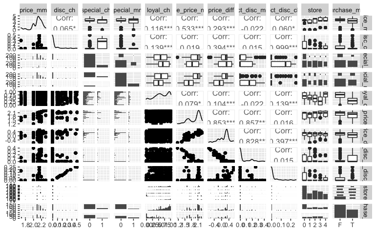

```r
juice_clean %>%
  ggpairs()
```

This initial plot is hard to read, so I will split it up

[output not shown]

[output cut: 15 more lines]

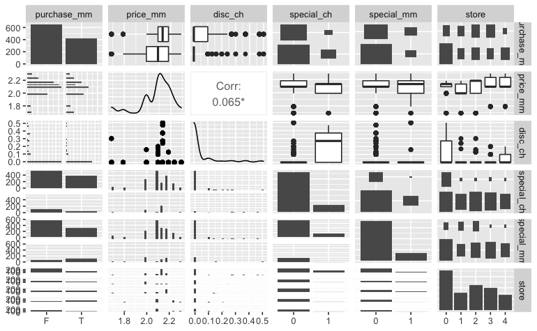

```r
juice_clean %>%
  select(purchase_mm, price_mm, disc_ch, special_ch, special_mm, store) %>%
  ggpairs()
```

[output not shown]

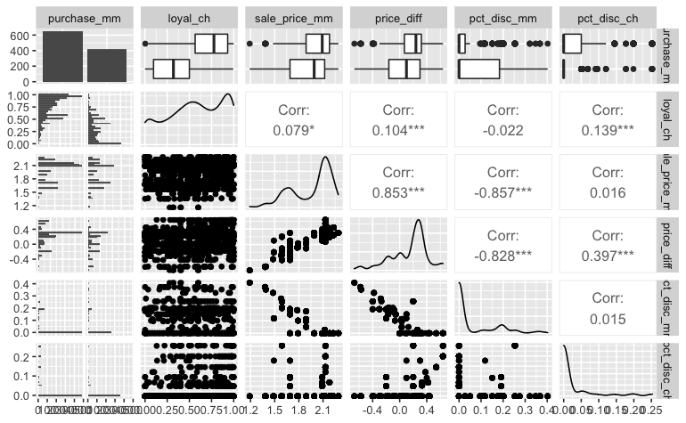

```r
juice_clean %>%
  select(purchase_mm, loyal_ch, sale_price_mm, price_diff, pct_disc_mm, pct_disc_ch) %>%
  ggpairs()
```

Based on the plots, the variables price_diff appears to have an impact. As does loyal_ch (there is a large variance in the mean). The store could also have an impact, but this could vary across the 5 levels. Lastly, sale_price, and special_ch, and special_mm, could also impact the model.

Therefore, I will include in my model: loyal_ch store sale_price special

Building 1st test model, with loyal_ch

```r
juice_model_1a <- glm(purchase_mm ~ loyal_ch,
                   data = juice_clean,
                   family = binomial(link = "logit"))

juice_1a_with_pred <- juice_clean %>%
  add_predictions(juice_model_1a, type = "response")

tidy(juice_model_1a)
```

| term | estimate | std.error | statistic | p.value |
| --- | --- | --- | --- | --- |
| (Intercept) | 2.755397 | 0.1995901 | 13.80528 | 2.368569e-43 |
| loyal_ch | -6.094763 | 0.3611485 | -16.87606 | 6.750426e-64 |

```r
roc_1a_pred <- juice_1a_with_pred %>%
  roc(response = purchase_mm, predictor = pred)
auc(roc_1a_pred)
```

```
Area under the curve: 0.874
```

Building 2nd test model, with store

```r
juice_model_1b <- glm(purchase_mm ~ store,
                   data = juice_clean,
                   family = binomial(link = "logit"))

juice_1b_with_pred <- juice_clean %>%
  add_predictions(juice_model_1b, type = "response")

tidy(juice_model_1b)
```

| term | estimate | std.error | statistic | p.value |
| --- | --- | --- | --- | --- |
| (Intercept) | -1.2064089 | 0.1258759 | -9.5841156 | 9.325309e-22 |
| store1 | 1.0404237 | 0.2037114 | 5.1073420 | 3.267220e-07 |
| store2 | 1.2785122 | 0.1840820 | 6.9453407 | 3.775481e-12 |
| store3 | 1.6847113 | 0.1935007 | 8.7064859 | 3.134411e-18 |
| store4 | -0.2162531 | 0.2486168 | -0.8698251 | 3.843960e-01 |

```r
roc_1b_pred <- juice_1b_with_pred %>%
  roc(response = purchase_mm, predictor = pred)
auc(roc_1b_pred)
```

```
Area under the curve: 0.6889
```

This is a stat sig model - but the AUC is less than loyal_ch.

```r
juice_model_1c <- glm(purchase_mm ~ sale_price_mm,
                   data = juice_clean,
                   family = binomial(link = "logit"))

juice_1c_with_pred <- juice_clean %>%
  add_predictions(juice_model_1c, type = "response")

tidy(juice_model_1c)
```

| term | estimate | std.error | statistic | p.value |
| --- | --- | --- | --- | --- |
| (Intercept) | 3.055783 | 0.4981496 | 6.134267 | 8.555253e-10 |
| sale_price_mm | -1.794702 | 0.2538166 | -7.070860 | 1.539768e-12 |

```r
roc_1c_pred <- juice_1c_with_pred %>%
  roc(response = purchase_mm, predictor = pred)
auc(roc_1c_pred)
```

```
Area under the curve: 0.6198
```

This is also less than the 1st model.

```r
juice_model_1d <- glm(purchase_mm ~ special_mm,
                   data = juice_clean,
                   family = binomial(link = "logit"))

juice_1d_with_pred <- juice_clean %>%
  add_predictions(juice_model_1d, type = "response")

tidy(juice_model_1d)
```

| term | estimate | std.error | statistic | p.value |
| --- | --- | --- | --- | --- |
| (Intercept) | -0.6090085 | 0.06989797 | -8.712821 | 2.964036e-18 |
| special_mm1 | 0.9474629 | 0.16933873 | 5.595075 | 2.205261e-08 |

```r
roc_1d_pred <- juice_1d_with_pred %>%
  roc(response = purchase_mm, predictor = pred)
auc(roc_1d_pred)
```

```
Area under the curve: 0.566
```

This is the lowest. Therefore, I will go with the first one, loyal_ch.

The first one I will try to add on, is store.

```r
juice_model_2a <- glm(purchase_mm ~ loyal_ch + store,
                   data = juice_clean,
                   family = binomial(link = "logit"))

juice_2a_with_pred <- juice_clean %>%
  add_predictions(juice_model_2a, type = "response")

tidy(juice_model_2a)
```

| term | estimate | std.error | statistic | p.value |
| --- | --- | --- | --- | --- |
| (Intercept) | 2.1418724 | 0.2427520 | 8.823296 | 1.111389e-18 |
| loyal_ch | -5.9675277 | 0.3775785 | -15.804733 | 2.886104e-56 |
| store1 | 0.8876730 | 0.2468555 | 3.595921 | 3.232455e-04 |
| store2 | 0.9004385 | 0.2307321 | 3.902528 | 9.519307e-05 |
| store3 | 0.6742595 | 0.2568387 | 2.625225 | 8.659160e-03 |
| store4 | 0.5793242 | 0.2967351 | 1.952328 | 5.089931e-02 |

```r
roc_2a_pred <- juice_2a_with_pred %>%
  roc(response = purchase_mm, predictor = pred)
auc(roc_2a_pred)
```

```
Area under the curve: 0.8809
```

This is marginally higher than loyal_ch alone, but still stat sign.

I will next try with sale_price_mm.

```r
juice_model_2b <- glm(purchase_mm ~ loyal_ch + sale_price_mm,
                   data = juice_clean,
                   family = binomial(link = "logit"))

juice_2b_with_pred <- juice_clean %>%
  add_predictions(juice_model_2b, type = "response")

tidy(juice_model_2b)
```

| term | estimate | std.error | statistic | p.value |
| --- | --- | --- | --- | --- |
| (Intercept) | 7.188767 | 0.7080294 | 10.153204 | 3.206605e-24 |
| loyal_ch | -6.222740 | 0.3714947 | -16.750547 | 5.610812e-63 |
| sale_price_mm | -2.261261 | 0.3344252 | -6.761635 | 1.364430e-11 |

```r
roc_2b_pred <- juice_2b_with_pred %>%
  roc(response = purchase_mm, predictor = pred)
auc(roc_2b_pred)
```

```
Area under the curve: 0.8895
```

This is also stat sign, and marginally higher still than store.

I will next try with special_mm.

```r
juice_model_2c <- glm(purchase_mm ~ loyal_ch + special_mm,
                   data = juice_clean,
                   family = binomial(link = "logit"))

juice_2c_with_pred <- juice_clean %>%
  add_predictions(juice_model_2c, type = "response")

tidy(juice_model_2c)
```

| term | estimate | std.error | statistic | p.value |
| --- | --- | --- | --- | --- |
| (Intercept) | 2.572374 | 0.2012465 | 12.78220 | 2.061440e-37 |
| loyal_ch | -6.104982 | 0.3647470 | -16.73758 | 6.976410e-63 |
| special_mm1 | 1.009894 | 0.2162272 | 4.67052 | 3.004387e-06 |

```r
roc_2c_pred <- juice_2c_with_pred %>%
  roc(response = purchase_mm, predictor = pred)
auc(roc_2c_pred)
```

```
Area under the curve: 0.8809
```

Next, I will plot the data.

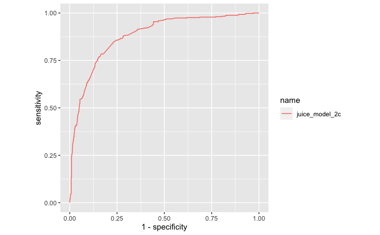

```r
ggroc(data = list(juice_model_2c = roc_2c_pred),
      legacy.axes = TRUE) +
  coord_fixed()
```

Visually, this looks like a good model.

For the sake of comparison, I’ll compare it to the other models.

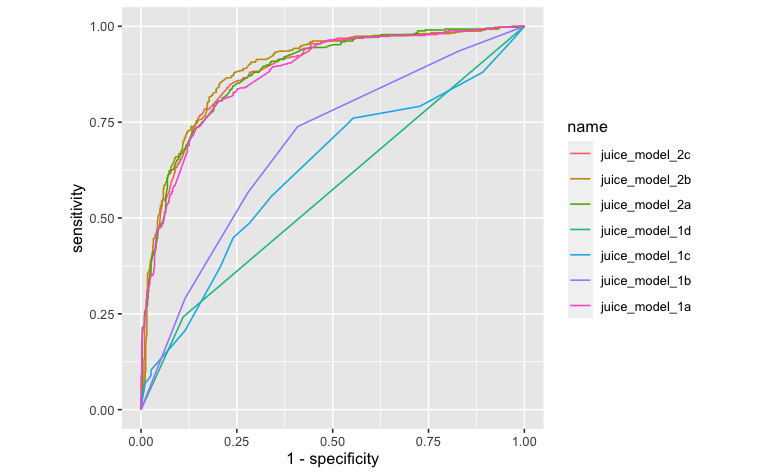

```r
ggroc(data = list(juice_model_2c = roc_2c_pred,
                  juice_model_2b = roc_2b_pred,
                  juice_model_2a = roc_2a_pred,
                  juice_model_1d = roc_1d_pred,
                  juice_model_1c = roc_1c_pred,
                  juice_model_1b = roc_1b_pred,
                  juice_model_1a = roc_1a_pred),
      legacy.axes = TRUE) +
  coord_fixed()
```

Interestingly, this shows that one model may have had a higher AUC (2b). I will check.

From checking the AUC values I calculated above, it is correct that model 2b is higher. Having used model 2c is a typographical error in my documentation, so it was good that I checked using the plot.

The correct model is 2b, as the AUC is slightly higher than 2c (as above in my calculations).

Lastly, I will now complete cross validation.

```r
# train the model
train_control <- trainControl(method = "repeatedcv",
                              number = 5,
                              repeats = 100,
                              savePredictions = TRUE,
                              classProbs = TRUE,
                              summaryFunction = twoClassSummary)
```

[output not shown]

I’ve used cross-validation to test/validate my model; it has a sensitivity of 86% and specificity of 73%. Therefore, it is reasonably good at using purchase_mm as a classifier for whether a customer is likely to buy citrus hill, or minute maid.